# What does the dam-building boom mean for life in the Mekong?

Wei Jing Ang

2024-10-04

```r
# Load libraries
library(tidyverse)
library(sf)
library(ggplot2)
library(patchwork)
library(ghibli)
library(ggrepel)
library(ggtext)
library(glue)
```

```r
# Load data
# Mekong river basin
countries <- read_sf("Data/Mekong_basin_countries/Mekong_basin_countries.shp")
basin <- read_sf("Data/Mekong_basin_delta/Mekong_basin_delta.shp")

# Dams
dams <- read_sf("Data/Dams_1055/Dams_1055.shp")
dams_main <- read_sf("Data/Dams_mainstream/Dams_mainstream.shp")
dams1980 <- read_sf("Data/1980/1980.shp") # 1980
dams1990 <- read_sf("Data/1990/1990_combi.shp") # 1990
dams2000 <- read_sf("Data/2000/2000_combi.shp") # 2000
dams2010 <- read_sf("Data/2010/2010_combi.shp") # 2010
dams2020 <- read_sf("Data/2020/2020_combi.shp") # 2020

# River and lake
river1 <- read_sf("Data/River_1/FLOW1_STRA_3_China.shp") # upper course
river2 <- read_sf("Data/River_2/FLOW1_STRA_5.shp") # middle course
river3 <- read_sf("Data/River_3/FLOW3_CLASS2_TS.shp") # lower course
lake <- read_sf("Data/Lake/HydroLAKES_TS_finer.shp") # Tonle Sap Lake
```

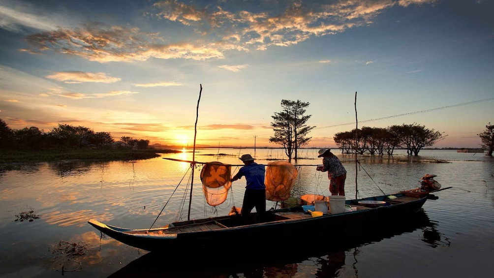

Fishermen on the Tonle Sap Lake of the Mekong River Basin

The Mekong River is the pulsing lifeline of Southeast Asia. With almost 1,200 unique fish species — of which 400 are found nowhere else on Earth — the Mekong’s rich biodiversity is rivaled only by the Amazon and the Congo.

As the world’s largest inland fishery, the Mekong accounts for more than 15% of global freshwater catch, supporting over 60 million locals dependent on the fishing industry.

The Mekong Delta, known as the “rice bowl of Southeast Asia”, contributes to 15% of global rice exports (Tri 2012). It is a vital agricultural region formed where the river meets the sea, home to nearly 20 million people in the agriculture and aquaculture industry.

Yet, the Mekong River is now clogged by a massive network of dams. In just the last ten years, more than 200 dams have sprung up across the Mekong River and its tributaries. Another 400 are planned for the next decade, expanding the current network by 60% and pushing the total projected dam count to exceed one thousand (Ang et al. 2023). Among the planned projects are 16 major hydropower dams that will double the length of the dam cascade along the mainstream Mekong.

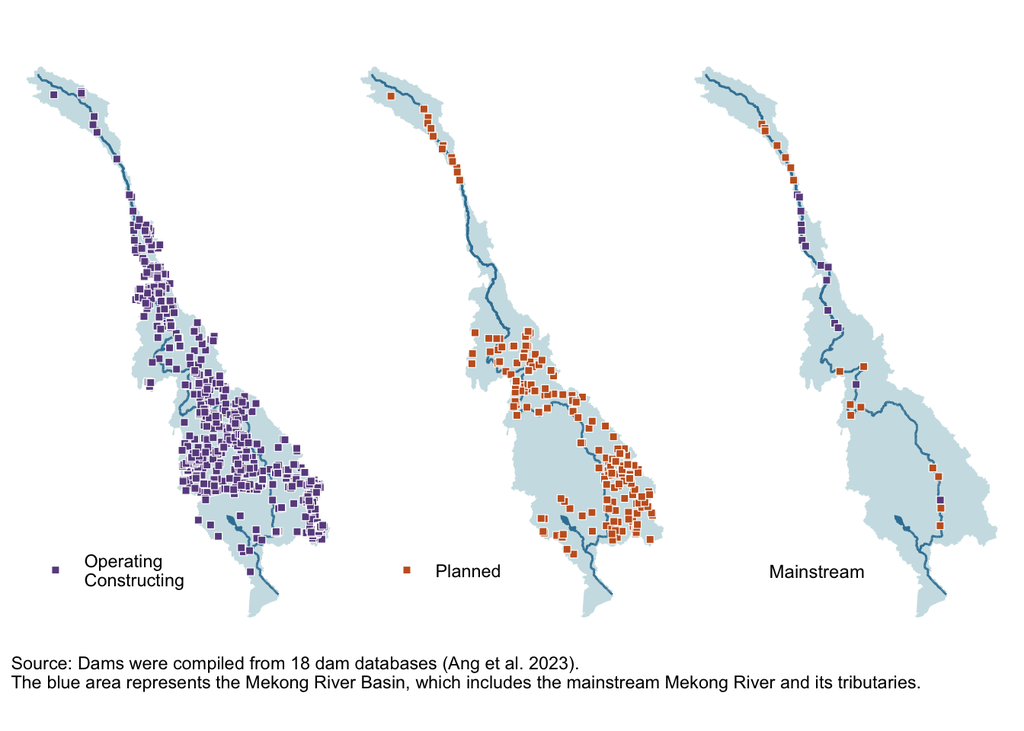

```r
# Base map of mekong basin
hbase <- ggplot() +
  geom_sf(data = basin, fill = "#CDE1E5", color = "transparent") + # lower basin
  geom_sf(data = rbind(river1, river2, river3), color = "#3981A4") + # river
  geom_sf(data = lake, fill = "#3981A4", color = "transparent") + # Tonle Sap Lake
  theme_void() +
  theme(legend.position = "inside",
        legend.position.inside = c(0.3,0.15)) # legend at bottom left

# With operating/ constructing dams
h1 <- hbase +
  geom_sf(data = dams %>%
            filter(Status == "Operational" | Status == "Under construction"),
          pch = 22, aes(fill = "#6A4E8E"), color = "white", size = 1.8, stroke = 0.3) +
          # pch 22: square markers, color: border, size: marker size, stroke: border thickness
  scale_fill_manual(values = "#6A4E8E",
                    name = "",
                    label = "Operating\nConstructing")

# With planned dams
h2 <- hbase +
  geom_sf(data = dams %>%
            filter(Status == "Planned"),
          pch = 22, aes(fill = "#C66125"), color = "white", size = 1.8, stroke = 0.3) +
  scale_fill_manual(values = "#C66125",
                    name = "",
                    label = "Planned")

# Mainstream dams
h3 <- hbase +
  geom_sf(data = dams_main %>%
            filter(Status == "Operational" | Status == "Under construction"),
          pch = 22, fill = "#6A4E8E", color = "white", size = 1.8, stroke = 0.3) +
  geom_sf(data = dams_main %>%
            filter(Status == "Planned"),
          pch = 22, fill = "#C66125", color = "white", size = 1.8, stroke = 0.3) +
  annotate("text", x = 99.9, y = 10.7, label = "Mainstream", size = 9/.pt) # mainstream label

h1 + h2 + h3 + plot_annotation(
  caption = "Source: Dams were compiled from 18 dam databases (Ang et al. 2023).\nThe blue area represents the Mekong River Basin, which includes the mainstream Mekong River and its tributaries."
) &
  theme(plot.caption = element_text(hjust = 0))
```

# Hydropower generation will double

The 3,000-mile Mekong is Southeast Asia’s longest river, flowing through six countries: China, Myanmar, Laos, Thailand, Cambodia, and Vietnam (Hirsch 2016). As these nations are experiencing rapid economic and population growth, dams — a relatively low-cost energy source in this water-rich region — have proliferated across the Mekong River Basin in response to rising energy demands (Hecht et al. 2019; International Renewable Energy Agency 2022). All six countries are competing for their share of the river while racing to dominate the hydropower market.

The total hydropower capacity, or the maximum power that can be generated by the entire dam network, had expanded exponentially from one gigawatt in the 1980s, to 35 gigawatts in the 2010s, and is projected to double to 70 gigawatts in the 2020s and beyond.

China was the first to harness the Mekong’s hydropower potential, as evidenced by its substantial expansion in hydropower capacity from the 2000s to the 2010s in the following graph (Cronin 2009). Having built 11 dams along the upper segment of the mainstream Mekong, China had become the focal point of discussions regarding the Mekong Basin, with many expressing concerns about the impact of upstream dams on reducing the water flow to downstream countries (Eyler 2020). However, the pace of dam construction in China is slowing as development gains momentum downstream.

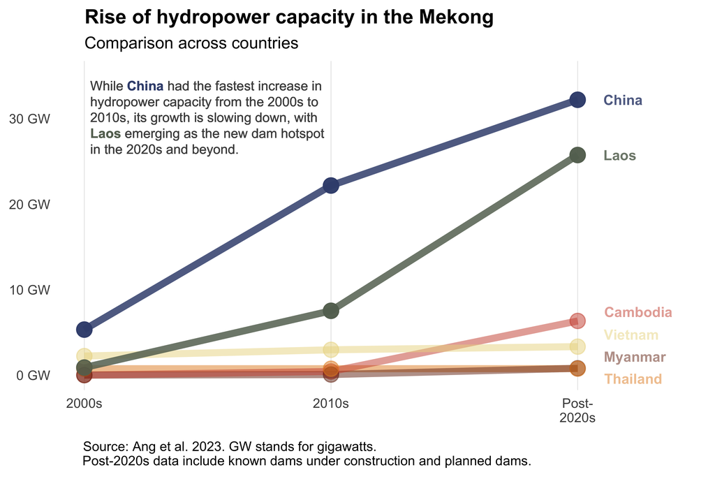

```r
# Define function to sum hydropower per country per decade
bycountry <- function(hpyear,year){
  hpyear %>%
  st_drop_geometry() %>%
  dplyr::select(Capacity_M, Country) %>%
  group_by(Country) %>%
  summarise(Capacity = sum(Capacity_M, na.rm = T)) %>%
  mutate(decade = year)
}

# Run function to sum hydropower
# Note: Myanmar only appears in 2010, so add in a row for Myanmar until 2000
country1980 <- bycountry(dams1980,1980) %>%
  rbind(.,data.frame(Country = "Myanmar",Capacity = 0, decade = 1980))
country1990 <- bycountry(dams1990,1990) %>%
  rbind(.,data.frame(Country = "Myanmar",Capacity = 0, decade = 1990))
country2000 <- bycountry(dams2000,2000) %>%
  rbind(.,data.frame(Country = "Myanmar",Capacity = 0, decade = 2000))
country2010 <- bycountry(dams2010,2010)
country2020 <- bycountry(dams2020,2020)
countryall <- rbind(country1980,country1990,country2000,country2010,country2020)

# Reorder the countries for a more organised slope graph
countryall$Country <- factor(countryall$Country,
                             levels = c('Thailand','Myanmar','Cambodia',
                                        'Vietnam','Laos','China'),ordered = TRUE)

annotation_text <- glue("While <span style='color:#3D4F7DFF;'>**China**</span> had the fastest increase in <br> hydropower capacity from the 2000s to <br> 2010s, its growth is slowing down, with <br> <span style='color:#657060FF;'>**Laos**</span> emerging as the new dam hotspot <br> in the 2020s and beyond.")

# Define palette
palette2 = ghibli_palette("MononokeMedium",direction=1)[c(6,2,5,7,4,3)]

# Slope graph of hydropower per country over time
ggplot(countryall %>%
               filter(decade > 1990),
             aes(x = decade, y = Capacity, group = Country,
                 label = Country, col = Country)) + # colour labels
  geom_line(aes(color = Country), size = 2) +
  geom_point(aes(color = Country), size = 4) +
  # can't fix the point drawing order for nuts so adding another layer of points for China and Laos
  geom_point(data = countryall %>%
               filter(decade > 1990 & Country == "Laos" | decade > 1990 & Country == "China"),
             aes(color = Country), size = 4) +
  scale_y_continuous(limits = c(NA,35000),
                     breaks=c(0,10000,20000,30000),
                     labels=c("0 GW","10 GW","20 GW","30 GW")) + # GW for cleaner graph
  scale_x_continuous(breaks=c(2000,2010,2020),
                     labels = c("2000s","2010s","Post-\n2020s"),
                     expand = expansion(mult = c(0.05,0.2))) +
  scale_color_manual(values = c(alpha(palette2[1:4],0.5),alpha(palette2[5:6],0.85)), name = NULL) +
  geom_text_repel(data = countryall %>%
                    filter(decade == 2020),
                  aes(label = Country,
                      hjust = "left",
                      fontface = "bold"),
                  nudge_x = 1,
                  segment.color = NA,
                  size = 3,
                  direction = "y") + # repel labels in y direction
  geom_richtext(aes(x = 2000, y = 30000,
                     label = annotation_text),
                size = 8/.pt,
                colour = "grey30",
                hjust = 0,
                fill = NA,
                label.color = NA) +
  labs(x = NULL, y = NULL,
       title = "Rise of hydropower capacity in the Mekong",
       subtitle = "Comparison across countries",
       caption = "Source: Ang et al. 2023. GW stands for gigawatts.\n   Post-2020s data include known dams under construction and planned dams.") + # spaces to shift Post-2020s to the right
  theme(plot.title = element_text(size = 12, face = "bold", hjust = 0.11),
        plot.subtitle = element_text(size = 10, hjust = 0.06),
        axis.ticks = element_blank(),
        axis.text = element_text(size=8),
        panel.background = element_blank(),
        panel.grid.major.x = element_line("grey80", size = 0.1),
        panel.grid.major.y = element_blank(),
        panel.grid.minor = element_blank(),
        legend.position = "none",
        plot.background = element_blank(),
        plot.caption = element_text(size=8, hjust = 0.07, margin=margin(10,0,0,0)))
```

# Laos as the next dam hotspot

With an ambitious goal of becoming the “Battery of Southeast Asia”, Laos has the most planned dams and the highest expected growth in hydropower capacity of nearly 20 gigawatts over the next decade. Laos was the third-largest exporter of electricity globally in 2020, with 90% imported by Thailand, and its exports are projected to more than triple by 2030 (Chowdhury et al. 2020; Economic Complexity 2023).

As shown in the sequence of maps below, Laos’ hydropower capacity is expected to grow significantly in the 2020s and beyond. The volume of a river’s flow increases downstream as more rainfall is progressively captured, and Laos’ strategic location along the lower mainstream Mekong provides key access to the greater flow volumes, which can be harnessed for increased hydropower (Biba 2012).

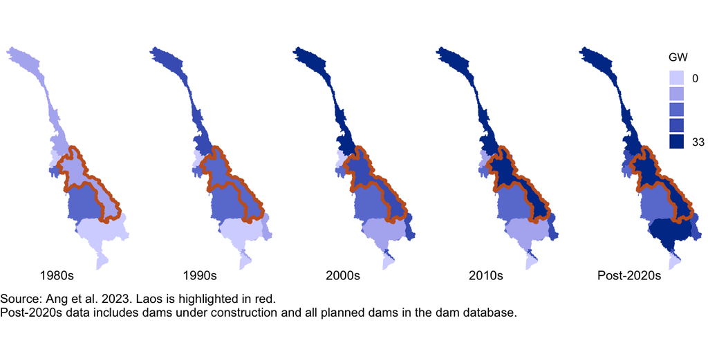

```r
# Add geometry to countryall
countries <- countries %>% rename(Country = COUNTRY) # rename for joining
countryall_withgeom <- left_join(countryall,
                                 countries %>%
                                   dplyr::select(geometry,Country),
                               by = "Country") %>% # left join geometries to country data
  st_as_sf(crs = st_crs(basin)) # turn into sf for mapping

# Decadal labels for the map
annotations <- data.frame(
  decade = c(1980, 1990, 2000, 2010, 2020),
  label = c("1980s", "1990s", "2000s", "2010s", "Post-2020s")
)

# Maps of hydropower capacity over the decades
ggplot()+
  geom_sf(data = basin, fill = "#D6D6FF", color = "transparent") +
  geom_sf(data = countryall_withgeom, aes(fill = as.factor(ntile(Capacity, 5))), # quintiles
          color = "transparent") +
  facet_wrap(~decade, nrow = 1) + # 1 map for each decade
  scale_fill_manual(values = c("#D6D6FF","#B2B4F0","#6B7ED4","#4561BF","#003995"),
                    name = "GW",
                    labels = c("0","","","","33")) +
  geom_sf(data = countries %>%
            filter(NAME == "Laos"), fill = "transparent", color = "#C66125", linewidth = 1) +
  geom_text(data = annotations, aes(x = 100, y = 8, label = label), size = 9/.pt) + # decadal labels
  theme_void() +
  labs(caption = "Source: Ang et al. 2023. Laos is highlighted in red.\nPost-2020s data includes dams under construction and all planned dams in the dam database.") +
  theme(
  strip.text.x = element_blank(), # remove facet wrap labels
  legend.position = "inside",
  legend.position.inside = c(0.97,0.74), # legend at top right
  legend.key.height = unit(0.4, "cm"), # reduce legend key size
  legend.key.width = unit(0.4, "cm"),
  legend.title = element_text(size = 8),
  legend.text = element_text(size = 8),
  plot.caption = element_text(hjust = 0)
)
```

# Livelihoods and food security

While dams are viewed as an alternative energy source to depleting fossil fuels, the surge in dam construction has become a threat to local livelihoods and regional food security. Dams fragment the river and obstruct the migratory routes for 5 billion fishes on the move, disrupting breeding patterns and contributing to the concerning reality that one-fifth of the Mekong River’s fish are now at risk of extinction (Hughes 2024; Tang et al. 2021).

Dams also block nutrient-rich sediments carried by the river from reaching the Mekong Delta. Starving the delta of these sediments is causing it to shrink and lose nutrients, jeopardizing food production and the livelihoods of locals in the agricultural sector (Grill et al. 2014).

Amidst the dam-building boom, safeguarding local communities and food security is crucial. However, dam planning and management in the Mekong is often haphazard and marred by embezzlement (Matthews 2012). Given limited resources, it would be strategic to target efforts in areas of greatest concern.

Laos’ plans for seven new massive dams on the Mekong mainstream, along with Cambodia’s plans for two, could collectively prevent up to 96% of river sediments from reaching the delta (Kondolf, Rubin, and Minear 2014). Future dam management efforts should focus on Laos, the emerging hotspot for hydropower development.

# References

Ang, Wei Jing, Edward Park, Dung Duc Tran, Ho Huu Loc, and Yadu Pokhrel. 2023. “Dams in the Mekong: A Comprehensive Database, Spatiotemporal Distribution, and Hydropower Potentials.” *Earth System Science Data Discussions* 2023: 1–30.

Biba, Sebastian. 2012. “China’s Continuous Dam-Building on the Mekong River.” *Journal of Contemporary Asia* 42 (4): 603–28.

Chowdhury, AFM Kamal, Thanh Duc Dang, Arijit Bagchi, and Stefano Galelli. 2020. “Expected Benefits of Laos’ Hydropower Development Curbed by Hydroclimatic Variability and Limited Transmission Capacity: Opportunities to Reform.” *Journal of Water Resources Planning and Management* 146 (10): 05020019.

Cronin, Richard. 2009. “Mekong Dams and the Perils of Peace.” *Survival* 51 (6): 147–60.

Economic Complexity, Observatory of. 2023. “Electricity in Laos, OEC – the Observatory of Economic Complexity.”

Eyler, Brian. 2020. “Science Shows Chinese Dams Are Devastating the Mekong.”

Grill, Günther, Camille Ouellet Dallaire, Etienne Fluet Chouinard, Nikolai Sindorf, and Bernhard Lehner. 2014. “Development of New Indicators to Evaluate River Fragmentation and Flow Regulation at Large Scales: A Case Study for the Mekong River Basin.” *Ecological Indicators* 45: 148–59.

Hecht, Jory S, Guillaume Lacombe, Mauricio E Arias, Thanh Duc Dang, and Thanapon Piman. 2019. “Hydropower Dams of the Mekong River Basin: A Review of Their Hydrological Impacts.” *Journal of Hydrology* 568: 285–300.

Hirsch, Philip. 2016. “The Shifting Regional Geopolitics of Mekong Dams.” *Political Geography* 51: 63–74.

Hughes, Kathy. 2024. “The Mekong’s Forgotten Fishes.” World Wildlife Fund, Gland, Switzerland.

International Renewable Energy Agency, Abu Dhabi. 2022. “IRENA: Renewable Power Generation Costs in 2021.”

Kondolf, George Mathias, Zan K Rubin, and JT Minear. 2014. “Dams on the Mekong: Cumulative Sediment Starvation.” *Water Resources Research* 50 (6): 5158–69.

Matthews, Nathanial. 2012. “Water Grabbing in the Mekong Basin-an Analysis of the Winners and Losers of Thailand’s Hydropower Development in Lao PDR.” *Water Alternatives* 5 (2).

Tang, Lei, Kangle Mo, Jianyun Zhang, Jun Wang, Qiuwen Chen, Shufeng He, Chenxi Zhu, and Yuqing Lin. 2021. “Removing Tributary Low-Head Dams Can Compensate for Fish Habitat Losses in Dammed Rivers.” *Journal of Hydrology* 598: 126204.

Tri, Vo Khac. 2012. “Hydrology and Hydraulic Infrastructure Systems in the Mekong Delta, Vietnam.” In *The Mekong Delta System: Interdisciplinary Analyses of a River Delta*, 49–81. Springer.